# Python Codes

1] Binary Search

2] Linear Search

3] Numpy Functions

4] Pandas

4.1] Unique and Nunique

4.2] Dealing with Duplicates

4.3] Drop and Del

4.4] Rank in DataFrame

4.5] Index related funtions

4.6] Rename, Replace and Map

4.7] Append DataFrame

4.8] Pivote Table and Pivote

4.9] Importing DataFrame

4.10] Isin function

4.11] Group By

4.12] Combining data frames

4.13] Merge and Join

4.14] Dataframe sort

5] EDA

6] Visualization

7.1] Append vs extend

7.2] Series Concatenation

#### Binary Search

```python
def binary_search (elements, low, high, x):
    if high >= low:
        mid = (low + high) // 2
        if elements[mid] == x:
            return mid
        # if element is smaller than mid, it is can be only in left sub tree
        elif elements[mid] > x:
            return binary_search(elements, low, mid-1, x)
        #else in right sub tree
        else:
            return binary_search(elements, mid+1, high, x)
    else:
        #not in the collection
        return -1
```

```python
elements = [3, 5, 8, 10, 35]
x = 10
answer = binary_search(elements, 0, len(elements)-1, x)
if answer == -1:
    print("Element is not present in array")
else:
    print("Element is present in array at index", str(answer))
```

```
Element is present in array at index 3
```

#### Linear Search

```python
def linear_search (elements, x):
    for i in range(0, len(elements)-1):
        if elements[i] == x:
            return i
    else:
        return -1
```

```python
import random
elements = [3, 5, 8, 10, 35]
x = 10
random.shuffle(elements)
print(elements)
answer = linear_search(elements, x)
if answer == -1:
    print("Element is not present in array")
else:
    print("Element is present in array at index", str(answer))
```

```
[35, 3, 5, 10, 8]
Element is present in array at index 3
```

#### Numpy Functions

NumPy refers to Numerical Python and it is an open source library in Python that aids in mathematical ,numerical calculations and computations , scientific, engineering, and data science programming.

NumPy is an most essential library to perform mathematical and statistical operations. It works perfectly well for multi-dimensional arrays and matrices multiplication.

Numpy is memory efficiency, meaning it can handle the vast amount of data more accessible than any other library. Besides, NumPy is very convenient to work with, especially for matrix multiplication and reshaping and more helpful in machine learning.

Numpy makes the work simpler by doing the complex numerical computations in background.

```python
import numpy as np
import pandas as pd
import matplotlib.pyplot as plt
%matplotlib inline
import warnings
warnings.filterwarnings('ignore')
```

```python
l_l = [[1,2],[3,4],[5,6]]         # List of lists
b=np.array(l_l)      # Here a list of lists is converted into 2 dimensional 3 X 2 array
print(b)
print(type(b))
print()
a = b.ravel()                  # ravel is used to convert 2 dimensional 3 X 2 array into 1D array
print(a)
type(a)
```

```
[[1 2]
 [3 4]
 [5 6]]
<class 'numpy.ndarray'>

[1 2 3 4 5 6]
```

```
numpy.ndarray
```

#### Lets see the `Conditional statements` on arrays

```python
ca = np.arange(9).reshape(3,3)
# 'arange' will take values from 0 to 8 and 'reshape' will form a 3 x 3 matrix of those values
print("The original array is \n" ,ca)

con = ca > 5
# Checking whether the values are greater than 5, it will return boolean and storing boolean output in a new variable

print(" \nThe boolean array after the conditional statement is applied \n")
print(con)

ca[con] # The boolean TRUE/FALSE array is now used for cherry picking inside a matrix
# it will print only the numbers satisfying the '> 5' condition
```

```
The original array is
 [[0 1 2]
 [3 4 5]
 [6 7 8]]

The boolean array after the conditional statement is applied

[[False False False]
 [False False False]
 [ True  True  True]]
```

```
array([6, 7, 8])
```

#### Lets see how to `Replace` all the elements of an array which is greater than 4 with zero

```python
ca = np.arange(9).reshape(3,3)
print("The original array is : \n", ca)

con = ca > 4
ca[con]=0        # This will replace all the values in matrix 'ca' which are greater than 4 with zero
print("\n",ca)
```

```
The original array is :
 [[0 1 2]
 [3 4 5]
 [6 7 8]]

 [[0 1 2]
 [3 4 0]
 [0 0 0]]
```

```python
newa = np.arange(10).reshape(2,5)
newb = np.arange(11,21).reshape(2,5)
print(newa)
print()
print(newb)
print()
newc=np.vstack((newa,newb))                # vstack is for vertical stacking of arrays

print(newc)
type(newc)
```

```
[[0 1 2 3 4]
 [5 6 7 8 9]]

[[11 12 13 14 15]
 [16 17 18 19 20]]

[[ 0  1  2  3  4]
 [ 5  6  7  8  9]
 [11 12 13 14 15]
 [16 17 18 19 20]]
```

```
numpy.ndarray
```

```python
newc=np.hstack((newa,newb))  # hstack is for Horizontal stacking of array

print(newc)
type(newc)
```

```
[[ 0  1  2  3  4 11 12 13 14 15]
 [ 5  6  7  8  9 16 17 18 19 20]]
```

```
numpy.ndarray
```

#### Lets see how can we `split` a large arrays into smaller arrays

```python
biga = np.arange(60).reshape(6,10)
print(biga)
print()
print(type(biga))
print()
print(biga.shape)
print()

sma = np.hsplit(biga,2)  # here 'hsplit' will divide the 'biga' in 2 smaller matrices
# the value '2' can be replaced with any other value, only condition is that it should be a factor of 'number of columns'
# Number of column here is '10' so 'hsplit' will work for 1,2 and 5
print(sma[0])
print()
print(sma[0].shape)
print()
print(sma[1])
print()
print(sma[1].shape)
```

```
[[ 0  1  2  3  4  5  6  7  8  9]
 [10 11 12 13 14 15 16 17 18 19]
 [20 21 22 23 24 25 26 27 28 29]
 [30 31 32 33 34 35 36 37 38 39]
 [40 41 42 43 44 45 46 47 48 49]
 [50 51 52 53 54 55 56 57 58 59]]

<class 'numpy.ndarray'>

(6, 10)

[[ 0  1  2  3  4]
 [10 11 12 13 14]
 [20 21 22 23 24]
 [30 31 32 33 34]
 [40 41 42 43 44]
 [50 51 52 53 54]]

(6, 5)

[[ 5  6  7  8  9]
 [15 16 17 18 19]
 [25 26 27 28 29]
 [35 36 37 38 39]
 [45 46 47 48 49]
 [55 56 57 58 59]]

(6, 5)
```

```python
print(np.hsplit(biga,1))
print()
print(type(np.hsplit(biga,1)))
```

```
[array([[ 0,  1,  2,  3,  4,  5,  6,  7,  8,  9],
       [10, 11, 12, 13, 14, 15, 16, 17, 18, 19],
       [20, 21, 22, 23, 24, 25, 26, 27, 28, 29],
       [30, 31, 32, 33, 34, 35, 36, 37, 38, 39],
       [40, 41, 42, 43, 44, 45, 46, 47, 48, 49],
       [50, 51, 52, 53, 54, 55, 56, 57, 58, 59]])]

<class 'list'>
```

#### Pandas

**`Data Structures` in pandas**

There are two basic data structures in pandas: Series and DataFrame

**Series**

It is similar to a NumPy 1-dimensional array. In addition to the values that are specified by the programmer, pandas attaches a label to each of the values. If the labels are not provided by the programmer, then pandas assigns labels ( 0 for first element, 1 for second element and so on). A benefit of assigning labels to data values is that it becomes easier to perform manipulations on the dataset as the whole dataset becomes more of a dictionary where each value is associated with a label.

**DataFrame**

DataFrame is a tabular data structure in which data is laid out in rows and column format (similar to a CSV or tables in SQL file), but it can also be used for higher dimensional data sets. The DataFrame object can contain homogenous and heterogenous values, and can be thought of as a logical extension of Series data structures. In contrast to Series, where there is one index, a DataFrame object has one index for column and one index for rows. This allows flexibility in accessing and manipulating data.

```python
import pandas as pd
```

```python
#Create a DataFrame
d = {                                                               # Creating a dict for dataframe
    'Name':['Alisa','Bobby','jodha','jack','raghu','Cathrine',
            'Alisa','Bobby','kumar','Alisa','Alex','Cathrine'],
    'Age':[26,24,23,22,23,24,26,24,22,23,24,24],

    'Score':[85,63,55,74,31,77,85,63,42,62,89,77]}

df = pd.DataFrame(d)                                # converting dict to dataframe
                                                    # Keys get converted to column names and values to column values
df
```

|  | Name | Age | Score |
| --- | --- | --- | --- |
| 0 | Alisa | 26 | 85 |
| 1 | Bobby | 24 | 63 |
| 2 | jodha | 23 | 55 |
| 3 | jack | 22 | 74 |
| 4 | raghu | 23 | 31 |
| 5 | Cathrine | 24 | 77 |
| 6 | Alisa | 26 | 85 |
| 7 | Bobby | 24 | 63 |
| 8 | kumar | 22 | 42 |
| 9 | Alisa | 23 | 62 |
| 10 | Alex | 24 | 89 |
| 11 | Cathrine | 24 | 77 |

**Q] How to get unique and number of unique values of a column**

```python
print(df['Name'].unique())       # It will all unique values in the column
print()
print(df['Name'].nunique())      # It will number unique values in the column
print()


print(df['Score'].unique())
print()
print(df['Score'].nunique())
print()
print(df['Score'].value_counts())
```

```
['Alisa' 'Bobby' 'jodha' 'jack' 'raghu' 'Cathrine' 'kumar' 'Alex']

8

[85 63 55 74 31 77 42 62 89]

9

63    2
77    2
85    2
62    1
74    1
89    1
55    1
42    1
31    1
Name: Score, dtype: int64
```

#### Dealing with duplicates

```python
df.drop_duplicates()      # It will drop duplicates of a row
#but keeps the first one
```

|  | Name | Age | Score |
| --- | --- | --- | --- |
| 0 | Alisa | 26 | 85 |
| 1 | Bobby | 24 | 63 |
| 2 | jodha | 23 | 55 |
| 3 | jack | 22 | 74 |
| 4 | raghu | 23 | 31 |
| 5 | Cathrine | 24 | 77 |
| 8 | kumar | 22 | 42 |
| 9 | Alisa | 23 | 62 |
| 10 | Alex | 24 | 89 |

**`Note` : If we run the code and output is visible than the changes does not occur in original dataframe, in order to see changes in original dataframe inplace = True or df = code has to be used**

**for example:**

**df = df.drop_duplicates()**

*or*

**df.drop_duplicates(inplace=True)**

```python
df.duplicated()     #return boolen value for the rows which are duplicated
```

```
0     False
1     False
2     False
3     False
4     False
5     False
6      True
7      True
8     False
9     False
10    False
11     True
dtype: bool
```

```python
df.drop_duplicates(keep='last')         # If we want to keep the last of the duplicated rows
```

|  | Name | Age | Score |
| --- | --- | --- | --- |
| 2 | jodha | 23 | 55 |
| 3 | jack | 22 | 74 |
| 4 | raghu | 23 | 31 |
| 6 | Alisa | 26 | 85 |
| 7 | Bobby | 24 | 63 |
| 8 | kumar | 22 | 42 |
| 9 | Alisa | 23 | 62 |
| 10 | Alex | 24 | 89 |
| 11 | Cathrine | 24 | 77 |

```python
df.drop_duplicates(['Name'], keep='last')  # If we want to drop duplicates based on rows of one attribute and keeps the last one
```

|  | Name | Age | Score |
| --- | --- | --- | --- |
| 2 | jodha | 23 | 55 |
| 3 | jack | 22 | 74 |
| 4 | raghu | 23 | 31 |
| 7 | Bobby | 24 | 63 |
| 8 | kumar | 22 | 42 |
| 9 | Alisa | 23 | 62 |
| 10 | Alex | 24 | 89 |
| 11 | Cathrine | 24 | 77 |

#### Drop and del in pandas

```python
df.drop([1,2])  # drops 1st and 2nd row
```

|  | Name | Age | Score |
| --- | --- | --- | --- |
| 0 | Alisa | 26 | 85 |
| 3 | jack | 22 | 74 |
| 4 | raghu | 23 | 31 |
| 5 | Cathrine | 24 | 77 |
| 6 | Alisa | 26 | 85 |
| 7 | Bobby | 24 | 63 |
| 8 | kumar | 22 | 42 |
| 9 | Alisa | 23 | 62 |
| 10 | Alex | 24 | 89 |
| 11 | Cathrine | 24 | 77 |

```python
df[df.Name != 'Alisa']    #drop the rows having name 'Alisa'
```

|  | Name | Age | Score |
| --- | --- | --- | --- |
| 1 | Bobby | 24 | 63 |
| 2 | jodha | 23 | 55 |
| 3 | jack | 22 | 74 |
| 4 | raghu | 23 | 31 |
| 5 | Cathrine | 24 | 77 |
| 7 | Bobby | 24 | 63 |
| 8 | kumar | 22 | 42 |
| 10 | Alex | 24 | 89 |
| 11 | Cathrine | 24 | 77 |

```python
df.drop(df.index[2])      # drops the second row
```

|  | Name | Age | Score |
| --- | --- | --- | --- |
| 0 | Alisa | 26 | 85 |
| 1 | Bobby | 24 | 63 |
| 3 | jack | 22 | 74 |
| 4 | raghu | 23 | 31 |
| 5 | Cathrine | 24 | 77 |
| 6 | Alisa | 26 | 85 |
| 7 | Bobby | 24 | 63 |
| 8 | kumar | 22 | 42 |
| 9 | Alisa | 23 | 62 |
| 10 | Alex | 24 | 89 |
| 11 | Cathrine | 24 | 77 |

```python
# Drop bottom 3 rows
df[:-3]
```

|  | Name | Age | Score |
| --- | --- | --- | --- |
| 0 | Alisa | 26 | 85 |
| 1 | Bobby | 24 | 63 |
| 2 | jodha | 23 | 55 |
| 3 | jack | 22 | 74 |
| 4 | raghu | 23 | 31 |
| 5 | Cathrine | 24 | 77 |
| 6 | Alisa | 26 | 85 |
| 7 | Bobby | 24 | 63 |
| 8 | kumar | 22 | 42 |

```python
# drop a column based on name

df.drop('Age',axis=1)
```

|  | Name | Score |
| --- | --- | --- |
| 0 | Alisa | 85 |
| 1 | Bobby | 63 |
| 2 | jodha | 55 |
| 3 | jack | 74 |
| 4 | raghu | 31 |
| 5 | Cathrine | 77 |
| 6 | Alisa | 85 |
| 7 | Bobby | 63 |
| 8 | kumar | 42 |
| 9 | Alisa | 62 |
| 10 | Alex | 89 |
| 11 | Cathrine | 77 |

```python
# drop a column based on column index

df.drop(df.columns[2],axis=1)
```

|  | Name | Age |
| --- | --- | --- |
| 0 | Alisa | 26 |
| 1 | Bobby | 24 |
| 2 | jodha | 23 |
| 3 | jack | 22 |
| 4 | raghu | 23 |
| 5 | Cathrine | 24 |
| 6 | Alisa | 26 |
| 7 | Bobby | 24 |
| 8 | kumar | 22 |
| 9 | Alisa | 23 |
| 10 | Alex | 24 |
| 11 | Cathrine | 24 |

```python
# delete a column

del df['Age']  #deletes it from the original dataframe
df
```

|  | Name | Score |
| --- | --- | --- |
| 0 | Alisa | 85 |
| 1 | Bobby | 63 |
| 2 | jodha | 55 |
| 3 | jack | 74 |
| 4 | raghu | 31 |
| 5 | Cathrine | 77 |
| 6 | Alisa | 85 |
| 7 | Bobby | 63 |
| 8 | kumar | 42 |
| 9 | Alisa | 62 |
| 10 | Alex | 89 |
| 11 | Cathrine | 77 |

#### Rank in DataFrame

```python
df['Subject'] = ['Mathematics','Mathematics','Mathematics','Science','Science','Science','History','History','History',
                 'Economics','Economics','Economics']             #creating a new column subjects

df = df[['Name','Subject','Score']] #setting order of columns
df
```

|  | Name | Subject | Score |
| --- | --- | --- | --- |
| 0 | Alisa | Mathematics | 85 |
| 1 | Bobby | Mathematics | 63 |
| 2 | jodha | Mathematics | 55 |
| 3 | jack | Science | 74 |
| 4 | raghu | Science | 31 |
| 5 | Cathrine | Science | 77 |
| 6 | Alisa | History | 85 |
| 7 | Bobby | History | 63 |
| 8 | kumar | History | 42 |
| 9 | Alisa | Economics | 62 |
| 10 | Alex | Economics | 89 |
| 11 | Cathrine | Economics | 77 |

```python
# Ranking of score in ascending order

df['score_rank']=df['Score'].rank()
df

# minimum value of score gets rank 1 and if score is same such as in case of rank
# 5, 5.5 is given to both and 6th is skipped
```

|  | Name | Subject | Score | score_rank |
| --- | --- | --- | --- | --- |
| 0 | Alisa | Mathematics | 85 | 10.5 |
| 1 | Bobby | Mathematics | 63 | 5.5 |
| 2 | jodha | Mathematics | 55 | 3.0 |
| 3 | jack | Science | 74 | 7.0 |
| 4 | raghu | Science | 31 | 1.0 |
| 5 | Cathrine | Science | 77 | 8.5 |
| 6 | Alisa | History | 85 | 10.5 |
| 7 | Bobby | History | 63 | 5.5 |
| 8 | kumar | History | 42 | 2.0 |
| 9 | Alisa | Economics | 62 | 4.0 |
| 10 | Alex | Economics | 89 | 12.0 |
| 11 | Cathrine | Economics | 77 | 8.5 |

```python
# Ranking of score in descending order

df['score_rank']=df['Score'].rank(ascending=False)
df

# maximum value of score gets rank 1 and if score is same such as in case of rank 2, 2.5 is given to both and 3rd is skipped
```

|  | Name | Subject | Score | score_rank |
| --- | --- | --- | --- | --- |
| 0 | Alisa | Mathematics | 85 | 2.5 |
| 1 | Bobby | Mathematics | 63 | 7.5 |
| 2 | jodha | Mathematics | 55 | 10.0 |
| 3 | jack | Science | 74 | 6.0 |
| 4 | raghu | Science | 31 | 12.0 |
| 5 | Cathrine | Science | 77 | 4.5 |
| 6 | Alisa | History | 85 | 2.5 |
| 7 | Bobby | History | 63 | 7.5 |
| 8 | kumar | History | 42 | 11.0 |
| 9 | Alisa | Economics | 62 | 9.0 |
| 10 | Alex | Economics | 89 | 1.0 |
| 11 | Cathrine | Economics | 77 | 4.5 |

```python
# Ranking of score in descending order based on min method of ranking

df['score_rank']=df['Score'].rank(ascending=0,method='min')
df

# maximum value of score gets rank 1
# if score is same of two values instead of giving 2 and 3 or 2.5 to both (mentioned above)
# it will give 2 to both and skip 3rd
```

|  | Name | Subject | Score | score_rank |
| --- | --- | --- | --- | --- |
| 0 | Alisa | Mathematics | 85 | 2.0 |
| 1 | Bobby | Mathematics | 63 | 7.0 |
| 2 | jodha | Mathematics | 55 | 10.0 |
| 3 | jack | Science | 74 | 6.0 |
| 4 | raghu | Science | 31 | 12.0 |
| 5 | Cathrine | Science | 77 | 4.0 |
| 6 | Alisa | History | 85 | 2.0 |
| 7 | Bobby | History | 63 | 7.0 |
| 8 | kumar | History | 42 | 11.0 |
| 9 | Alisa | Economics | 62 | 9.0 |
| 10 | Alex | Economics | 89 | 1.0 |
| 11 | Cathrine | Economics | 77 | 4.0 |

```python
# Ranking of score in descending order based on dense method of ranking

df['score_rank']=df['Score'].rank(ascending=0,method='dense')
df

# maximum value of score gets rank 1
# if score is same of two values
# it will give 2nd to both and 4th value will be ranked as 3rd
# no number is skipped here
```

|  | Name | Subject | Score | score_rank |
| --- | --- | --- | --- | --- |
| 0 | Alisa | Mathematics | 85 | 2.0 |
| 1 | Bobby | Mathematics | 63 | 5.0 |
| 2 | jodha | Mathematics | 55 | 7.0 |
| 3 | jack | Science | 74 | 4.0 |
| 4 | raghu | Science | 31 | 9.0 |
| 5 | Cathrine | Science | 77 | 3.0 |
| 6 | Alisa | History | 85 | 2.0 |
| 7 | Bobby | History | 63 | 5.0 |
| 8 | kumar | History | 42 | 8.0 |
| 9 | Alisa | Economics | 62 | 6.0 |
| 10 | Alex | Economics | 89 | 1.0 |
| 11 | Cathrine | Economics | 77 | 3.0 |

```python
# Rank the dataframe in python pandas by Group.

df["group_rank"] = df.groupby("Subject")["Score"].rank(ascending=0,method='dense')
df

# ranks are given based on each subject
# maximum value gets rank 1 and no number is skipped
```

|  | Name | Subject | Score | score_rank | group_rank |
| --- | --- | --- | --- | --- | --- |
| 0 | Alisa | Mathematics | 85 | 2.0 | 1.0 |
| 1 | Bobby | Mathematics | 63 | 5.0 | 2.0 |
| 2 | jodha | Mathematics | 55 | 7.0 | 3.0 |
| 3 | jack | Science | 74 | 4.0 | 2.0 |
| 4 | raghu | Science | 31 | 9.0 | 3.0 |
| 5 | Cathrine | Science | 77 | 3.0 | 1.0 |
| 6 | Alisa | History | 85 | 2.0 | 1.0 |
| 7 | Bobby | History | 63 | 5.0 | 2.0 |
| 8 | kumar | History | 42 | 8.0 | 3.0 |
| 9 | Alisa | Economics | 62 | 6.0 | 3.0 |
| 10 | Alex | Economics | 89 | 1.0 | 1.0 |
| 11 | Cathrine | Economics | 77 | 3.0 | 2.0 |

#### Index related Functions

```python
#creating new DataFrame
d = {
    'Name':['Alisa','Bobby','Cathrine','Alisa','Bobby','Cathrine',
            'Alisa','Bobby','Cathrine','Alisa','Bobby','Cathrine'],
    'Exam':['Semester 1','Semester 1','Semester 1','Semester 1','Semester 1','Semester 1',
            'Semester 2','Semester 2','Semester 2','Semester 2','Semester 2','Semester 2'],

    'Subject':['Mathematics','Mathematics','Mathematics','Science','Science','Science',
               'Mathematics','Mathematics','Mathematics','Science','Science','Science'],
   'Score':[62,47,55,74,31,77,85,63,42,67,89,81]}

df = pd.DataFrame(d)
df
```

|  | Name | Exam | Subject | Score |
| --- | --- | --- | --- | --- |
| 0 | Alisa | Semester 1 | Mathematics | 62 |
| 1 | Bobby | Semester 1 | Mathematics | 47 |
| 2 | Cathrine | Semester 1 | Mathematics | 55 |
| 3 | Alisa | Semester 1 | Science | 74 |
| 4 | Bobby | Semester 1 | Science | 31 |
| 5 | Cathrine | Semester 1 | Science | 77 |
| 6 | Alisa | Semester 2 | Mathematics | 85 |
| 7 | Bobby | Semester 2 | Mathematics | 63 |
| 8 | Cathrine | Semester 2 | Mathematics | 42 |
| 9 | Alisa | Semester 2 | Science | 67 |
| 10 | Bobby | Semester 2 | Science | 89 |
| 11 | Cathrine | Semester 2 | Science | 81 |

```python
df1=df.set_index(['Exam', 'Subject'])  #new dataframe df1 with tw0 index's (exam and subject)
df1
```

| Exam | Subject | Name | Score |
| --- | --- | --- | --- |
| Semester 1 | Mathematics | Alisa | 62 |
|  | Mathematics | Bobby | 47 |
|  | Mathematics | Cathrine | 55 |
|  | Science | Alisa | 74 |
|  | Science | Bobby | 31 |
|  | Science | Cathrine | 77 |
| Semester 2 | Mathematics | Alisa | 85 |
|  | Mathematics | Bobby | 63 |
|  | Mathematics | Cathrine | 42 |
|  | Science | Alisa | 67 |
|  | Science | Bobby | 89 |
|  | Science | Cathrine | 81 |

```python
# View index
df1.index
```

```
MultiIndex([('Semester 1', 'Mathematics'),
            ('Semester 1', 'Mathematics'),
            ('Semester 1', 'Mathematics'),
            ('Semester 1',     'Science'),
            ('Semester 1',     'Science'),
            ('Semester 1',     'Science'),
            ('Semester 2', 'Mathematics'),
            ('Semester 2', 'Mathematics'),
            ('Semester 2', 'Mathematics'),
            ('Semester 2',     'Science'),
            ('Semester 2',     'Science'),
            ('Semester 2',     'Science')],
           names=['Exam', 'Subject'])
```

```python
df1.reset_index() # to reset the index as 0,1,2....
```

|  | Exam | Subject | Name | Score |
| --- | --- | --- | --- | --- |
| 0 | Semester 1 | Mathematics | Alisa | 62 |
| 1 | Semester 1 | Mathematics | Bobby | 47 |
| 2 | Semester 1 | Mathematics | Cathrine | 55 |
| 3 | Semester 1 | Science | Alisa | 74 |
| 4 | Semester 1 | Science | Bobby | 31 |
| 5 | Semester 1 | Science | Cathrine | 77 |
| 6 | Semester 2 | Mathematics | Alisa | 85 |
| 7 | Semester 2 | Mathematics | Bobby | 63 |
| 8 | Semester 2 | Mathematics | Cathrine | 42 |
| 9 | Semester 2 | Science | Alisa | 67 |
| 10 | Semester 2 | Science | Bobby | 89 |
| 11 | Semester 2 | Science | Cathrine | 81 |

```python
df1.reset_index(inplace=True) # here inplace will apply the changes in the original dataframe 'df1'
```

#### Rename, Replace and Map

```python
print("Columns before Renaming")
print(df1.columns)
print()
print("Index before Renaming")
print(df1.index)
print()

df1.rename(columns={'Subject':'Sub','Score':'Marks'},index={0:'a',1:'b'},inplace = True)

print("Columns after Renaming")
print(df1.columns)
print()
print("Index after Renaming")
print(df1.index)
```

```
Columns before Renaming
Index(['Exam', 'Subject', 'Name', 'Score'], dtype='object')

Index before Renaming
RangeIndex(start=0, stop=12, step=1)

Columns after Renaming
Index(['Exam', 'Sub', 'Name', 'Marks'], dtype='object')

Index after Renaming
Index(['a', 'b', 2, 3, 4, 5, 6, 7, 8, 9, 10, 11], dtype='object')
```

```python
df1.replace(['Semester 1','Semester 2'],['Sem 1','Sem 2'])
```

|  | Exam | Sub | Name | Marks |
| --- | --- | --- | --- | --- |
| a | Sem 1 | Mathematics | Alisa | 62 |
| b | Sem 1 | Mathematics | Bobby | 47 |
| 2 | Sem 1 | Mathematics | Cathrine | 55 |
| 3 | Sem 1 | Science | Alisa | 74 |
| 4 | Sem 1 | Science | Bobby | 31 |
| 5 | Sem 1 | Science | Cathrine | 77 |
| 6 | Sem 2 | Mathematics | Alisa | 85 |
| 7 | Sem 2 | Mathematics | Bobby | 63 |
| 8 | Sem 2 | Mathematics | Cathrine | 42 |
| 9 | Sem 2 | Science | Alisa | 67 |
| 10 | Sem 2 | Science | Bobby | 89 |
| 11 | Sem 2 | Science | Cathrine | 81 |

```python
sub = {'Mathematics':'Maths','Science':'Sci'}

df1['Sub'].map(sub)
```

```
a     Maths
b     Maths
2     Maths
3       Sci
4       Sci
5       Sci
6     Maths
7     Maths
8     Maths
9       Sci
10      Sci
11      Sci
Name: Sub, dtype: object
```

#### Append in DataFrame

```python
left_frame = pd.DataFrame({'key': range(5),
                           'left_value': ['a', 'b', 'c', 'd', 'e']})
right_frame = pd.DataFrame({'key': range(2, 7),
                           'right_value': ['f', 'g', 'h', 'i', 'j']})

f = left_frame.append(right_frame, sort=True) #appended dataframe stored in 'f'
                                              #columns are sorted alphabetically due to 'sort=True'
print(f)
```

```
   key left_value right_value
0    0          a         NaN
1    1          b         NaN
2    2          c         NaN
3    3          d         NaN
4    4          e         NaN
0    2        NaN           f
1    3        NaN           g
2    4        NaN           h
3    5        NaN           i
4    6        NaN           j
```

```python
left_frame.append(right_frame, ignore_index=True, sort=True) #ignore index changes the value of index irrespective of two tables
```

|  | key | left_value | right_value |
| --- | --- | --- | --- |
| 0 | 0 | a | NaN |
| 1 | 1 | b | NaN |
| 2 | 2 | c | NaN |
| 3 | 3 | d | NaN |
| 4 | 4 | e | NaN |
| 5 | 2 | NaN | f |
| 6 | 3 | NaN | g |
| 7 | 4 | NaN | h |
| 8 | 5 | NaN | i |
| 9 | 6 | NaN | j |

#### Pivot Table and Pivot

```python
#creating new DataFrame
d = {
    'Name':['Alisa','Bobby','Cathrine','Alisa','Bobby','Cathrine',
            'Alisa','Bobby','Cathrine','Alisa','Bobby','Cathrine'],
    'Exam':['Semester 1','Semester 1','Semester 1','Semester 1','Semester 1','Semester 1',
            'Semester 2','Semester 2','Semester 2','Semester 2','Semester 2','Semester 2'],

    'Subject':['Mathematics','Mathematics','Mathematics','Science','Science','Science',
               'Mathematics','Mathematics','Mathematics','Science','Science','Science'],
   'Score':[62,47,55,74,31,77,85,63,42,67,89,81]}

df = pd.DataFrame(d)
df
```

|  | Name | Exam | Subject | Score |
| --- | --- | --- | --- | --- |
| 0 | Alisa | Semester 1 | Mathematics | 62 |
| 1 | Bobby | Semester 1 | Mathematics | 47 |
| 2 | Cathrine | Semester 1 | Mathematics | 55 |
| 3 | Alisa | Semester 1 | Science | 74 |
| 4 | Bobby | Semester 1 | Science | 31 |
| 5 | Cathrine | Semester 1 | Science | 77 |
| 6 | Alisa | Semester 2 | Mathematics | 85 |
| 7 | Bobby | Semester 2 | Mathematics | 63 |
| 8 | Cathrine | Semester 2 | Mathematics | 42 |
| 9 | Alisa | Semester 2 | Science | 67 |
| 10 | Bobby | Semester 2 | Science | 89 |
| 11 | Cathrine | Semester 2 | Science | 81 |

```python
pv=pd.pivot_table(df,index=['Name','Subject'],aggfunc='sum',values='Score')
pv

## Coverting dataframe to pivot table to obatin sum of marks obtained in each course
```

| Name | Subject | Score |
| --- | --- | --- |
| Alisa | Mathematics | 147 |
|  | Science | 141 |
| Bobby | Mathematics | 110 |
|  | Science | 120 |
| Cathrine | Mathematics | 97 |
|  | Science | 158 |

```python
pv=pd.pivot_table(df,index=['Name','Exam'],aggfunc='sum',values='Score')
pv

## Coverting dataframe to pivot table to obatin sum of marks obtained in each course duration
```

| Name | Exam | Score |
| --- | --- | --- |
| Alisa | Semester 1 | 136 |
|  | Semester 2 | 152 |
| Bobby | Semester 1 | 78 |
|  | Semester 2 | 152 |
| Cathrine | Semester 1 | 132 |
|  | Semester 2 | 123 |

```python
#creating new dataframe

d={'Date':['5/1/17','5/2/17','5/3/17','5/4/17','5/1/17','5/2/17','5/3/17','5/4/17'],
  'City':['NY','NY','NY','NY','LA','LA','LA','LA'],
  'Temp':[32,33,35,44,42,42,44,32],
  'Humidity':[51,53,54,67,56,51,74,72]}

df=pd.DataFrame(d)

df
```

|  | Date | City | Temp | Humidity |
| --- | --- | --- | --- | --- |
| 0 | 5/1/17 | NY | 32 | 51 |
| 1 | 5/2/17 | NY | 33 | 53 |
| 2 | 5/3/17 | NY | 35 | 54 |
| 3 | 5/4/17 | NY | 44 | 67 |
| 4 | 5/1/17 | LA | 42 | 56 |
| 5 | 5/2/17 | LA | 42 | 51 |
| 6 | 5/3/17 | LA | 44 | 74 |
| 7 | 5/4/17 | LA | 32 | 72 |

```python
## Lets reshape our data : Row = city and date , Column = Temperatre and Humidity

df.pivot(index='Date', columns='City')
```

| City Date | Temp LA | Temp NY | Humidity LA | Humidity NY |
| --- | --- | --- | --- | --- |
| 5/1/17 | 42 | 32 | 56 | 51 |
| 5/2/17 | 42 | 33 | 51 | 53 |
| 5/3/17 | 44 | 35 | 74 | 54 |
| 5/4/17 | 32 | 44 | 72 | 67 |

```python
## Lets reshape our data : Row = city and humidity , Column = Temperatre and date

df.pivot(index='Humidity',columns='City')
```

| City Humidity | Date LA | Date NY | Temp LA | Temp NY |
| --- | --- | --- | --- | --- |
| 51 | 5/2/17 | 5/1/17 | 42.0 | 32.0 |
| 53 | NaN | 5/2/17 | NaN | 33.0 |
| 54 | NaN | 5/3/17 | NaN | 35.0 |
| 56 | 5/1/17 | NaN | 42.0 | NaN |
| 67 | NaN | 5/4/17 | NaN | 44.0 |
| 72 | 5/4/17 | NaN | 32.0 | NaN |
| 74 | 5/3/17 | NaN | 44.0 | NaN |

#### Importing Datasets

Importing DataFrame codes cannot be reproduced as dataframes are not present in your PC.

#### 1] If the Dataset is separated by space and doesn't have column names

For Example:

pd.read_csv ('file_name',sep='separator_between_columns',names=['a','b','c','d'])

separators can be of different types, need to see the dataset in order to recognize correct dataset. **" "** or **"\t"** or **"|"** etc.

'names' consist name of the columns, If there are 4 columns in total then 'names' should consist of four column name, or else if one name is missed that it would not show one column in output

```python
import pandas as pd
pd.read_csv('u.data',sep="\t",names=['user_id','item_id','rating','timestamp']).head()
```

|  | user_id | item_id | rating | timestamp |
| --- | --- | --- | --- | --- |
| 0 | 196 | 242 | 3 | 881250949 |
| 1 | 186 | 302 | 3 | 891717742 |
| 2 | 22 | 377 | 1 | 878887116 |
| 3 | 244 | 51 | 2 | 880606923 |
| 4 | 166 | 346 | 1 | 886397596 |

#### 2] Encoding error while importing

By default the encoding of a file python takes it as 'UTF-8' but if encoding error occurs than try different encoders, such as "latin-1" works more complex datasets containig web address etc.

```python
pd.read_csv('u.item',sep="|",encoding="latin-1",names=list("ABCDEFGHIJKLMNOPQRSTUVWX")).head()
```

|  | A | B | C | D | E | F | G | H | I | J | ... | O | P | Q | R | S | T | U | V | W | X |
| --- | --- | --- | --- | --- | --- | --- | --- | --- | --- | --- | --- | --- | --- | --- | --- | --- | --- | --- | --- | --- | --- |
| 0 | 1 | Toy Story (1995) | 01-Jan-1995 | NaN | http://us.imdb.com/M/title-exact?Toy%20Story%2... | 0 | 0 | 0 | 1 | 1 | ... | 0 | 0 | 0 | 0 | 0 | 0 | 0 | 0 | 0 | 0 |
| 1 | 2 | GoldenEye (1995) | 01-Jan-1995 | NaN | http://us.imdb.com/M/title-exact?GoldenEye%20(... | 0 | 1 | 1 | 0 | 0 | ... | 0 | 0 | 0 | 0 | 0 | 0 | 0 | 1 | 0 | 0 |
| 2 | 3 | Four Rooms (1995) | 01-Jan-1995 | NaN | http://us.imdb.com/M/title-exact?Four%20Rooms%... | 0 | 0 | 0 | 0 | 0 | ... | 0 | 0 | 0 | 0 | 0 | 0 | 0 | 1 | 0 | 0 |
| 3 | 4 | Get Shorty (1995) | 01-Jan-1995 | NaN | http://us.imdb.com/M/title-exact?Get%20Shorty%... | 0 | 1 | 0 | 0 | 0 | ... | 0 | 0 | 0 | 0 | 0 | 0 | 0 | 0 | 0 | 0 |
| 4 | 5 | Copycat (1995) | 01-Jan-1995 | NaN | http://us.imdb.com/M/title-exact?Copycat%20(1995) | 0 | 0 | 0 | 0 | 0 | ... | 0 | 0 | 0 | 0 | 0 | 0 | 0 | 1 | 0 | 0 |

5 rows × 24 columns

#### 3] Importing excel dataset from different sheets

If sheet name is not mentioned by default it will take first sheet.

```python
pd.read_excel("data_ex.xlsx").head()
```

|  | user id | movie id | rating | timestamp |
| --- | --- | --- | --- | --- |
| 0 | 196 | 242 | 3 | 881250949 |
| 1 | 186 | 302 | 3 | 891717742 |
| 2 | 22 | 377 | 1 | 878887116 |
| 3 | 244 | 51 | 2 | 880606923 |
| 4 | 166 | 346 | 1 | 886397596 |

```python
pd.read_excel("data_ex.xlsx",sheet_name='Sheet2').head()
```

|  | user id | age | gender | occupation | zip code |
| --- | --- | --- | --- | --- | --- |
| 0 | 1 | 24 | M | technician | 85711 |
| 1 | 2 | 53 | F | other | 94043 |
| 2 | 3 | 23 | M | writer | 32067 |
| 3 | 4 | 24 | M | technician | 43537 |
| 4 | 5 | 33 | F | other | 15213 |

```python
pd.read_excel("data_ex.xlsx",sheet_name='Item').head()
```

|  | movie id | movie title | release date | unknown | Action | Adventure | Animation | Childrens | Comedy | Crime | ... | Fantasy | Film-Noir | Horror | Musical | Mystery | Romance | Sci-Fi | Thriller | War | Western |
| --- | --- | --- | --- | --- | --- | --- | --- | --- | --- | --- | --- | --- | --- | --- | --- | --- | --- | --- | --- | --- | --- |
| 0 | 1 | Toy Story | 1995-01-01 | 0 | 0 | 0 | 1 | 1 | 1 | 0 | ... | 0 | 0 | 0 | 0 | 0 | 0 | 0 | 0 | 0 | 0 |
| 1 | 2 | GoldenEye | 1995-01-01 | 0 | 1 | 1 | 0 | 0 | 0 | 0 | ... | 0 | 0 | 0 | 0 | 0 | 0 | 0 | 1 | 0 | 0 |
| 2 | 3 | Four Rooms | 1995-01-01 | 0 | 0 | 0 | 0 | 0 | 0 | 0 | ... | 0 | 0 | 0 | 0 | 0 | 0 | 0 | 1 | 0 | 0 |
| 3 | 4 | Get Shorty | 1995-01-01 | 0 | 1 | 0 | 0 | 0 | 1 | 0 | ... | 0 | 0 | 0 | 0 | 0 | 0 | 0 | 0 | 0 | 0 |
| 4 | 5 | Copycat | 1995-01-01 | 0 | 0 | 0 | 0 | 0 | 0 | 1 | ... | 0 | 0 | 0 | 0 | 0 | 0 | 0 | 1 | 0 | 0 |

5 rows × 22 columns

#### isin() function

**Q] How to check wheather elements of the list are in a column of the dataframe?**

`check if names present in list 'l1' are in data frame or not, if yes print only names present is the list as different dataframe`

```python
l1 = ['Alisa', 'Bobby'] # list containing names
```

```python
# Creating new DataFrame

import pandas as pd

#Creating a Dictionary with necessary data
d = {'Name':['Alisa','Bobby','Cathrine','Alisa','Bobby','Cathrine',
             'Alisa','Bobby','Cathrine','Alisa','Bobby','Cathrine'],
     'Exam':['Semester 1','Semester 1','Semester 1','Semester 1','Semester 1','Semester 1',
             'Semester 2','Semester 2','Semester 2','Semester 2','Semester 2','Semester 2'],
     'Subject':['Mathematics','Mathematics','Mathematics','Science','Science','Science',
                'Mathematics','Mathematics','Mathematics','Science','Science','Science'],
     'Score':[62,47,55,74,31,77,85,63,42,67,89,81],
    'Attendance':[75,89,94,68,78,90,80,62,81,65,98,99]}

# Converting Dictionary to DataFrame
df = pd.DataFrame(d)
df
```

|  | Name | Exam | Subject | Score | Attendance |
| --- | --- | --- | --- | --- | --- |
| 0 | Alisa | Semester 1 | Mathematics | 62 | 75 |
| 1 | Bobby | Semester 1 | Mathematics | 47 | 89 |
| 2 | Cathrine | Semester 1 | Mathematics | 55 | 94 |
| 3 | Alisa | Semester 1 | Science | 74 | 68 |
| 4 | Bobby | Semester 1 | Science | 31 | 78 |
| 5 | Cathrine | Semester 1 | Science | 77 | 90 |
| 6 | Alisa | Semester 2 | Mathematics | 85 | 80 |
| 7 | Bobby | Semester 2 | Mathematics | 63 | 62 |
| 8 | Cathrine | Semester 2 | Mathematics | 42 | 81 |
| 9 | Alisa | Semester 2 | Science | 67 | 65 |
| 10 | Bobby | Semester 2 | Science | 89 | 98 |
| 11 | Cathrine | Semester 2 | Science | 81 | 99 |

```python
df[df['Name'].isin(l1)]

# First it checks whether the 'name' column in df has the names present in 'l1'
# if present ouput will be true, and then
# df[ ] is used to slice those particular rows of the column
```

|  | Name | Exam | Subject | Score | Attendance |
| --- | --- | --- | --- | --- | --- |
| 0 | Alisa | Semester 1 | Mathematics | 62 | 75 |
| 1 | Bobby | Semester 1 | Mathematics | 47 | 89 |
| 3 | Alisa | Semester 1 | Science | 74 | 68 |
| 4 | Bobby | Semester 1 | Science | 31 | 78 |
| 6 | Alisa | Semester 2 | Mathematics | 85 | 80 |
| 7 | Bobby | Semester 2 | Mathematics | 63 | 62 |
| 9 | Alisa | Semester 2 | Science | 67 | 65 |
| 10 | Bobby | Semester 2 | Science | 89 | 98 |

### Group BY

```python
print(df)
x = df.groupby('Subject')
x
```

```
        Name        Exam      Subject  Score  Attendance
0      Alisa  Semester 1  Mathematics     62          75
1      Bobby  Semester 1  Mathematics     47          89
2   Cathrine  Semester 1  Mathematics     55          94
3      Alisa  Semester 1      Science     74          68
4      Bobby  Semester 1      Science     31          78
5   Cathrine  Semester 1      Science     77          90
6      Alisa  Semester 2  Mathematics     85          80
7      Bobby  Semester 2  Mathematics     63          62
8   Cathrine  Semester 2  Mathematics     42          81
9      Alisa  Semester 2      Science     67          65
10     Bobby  Semester 2      Science     89          98
11  Cathrine  Semester 2      Science     81          99
```

```
<pandas.core.groupby.generic.DataFrameGroupBy object at 0x118e27bb0>
```

```python
x.get_group("Science")
```

|  | Name | Exam | Subject | Score | Attendance |
| --- | --- | --- | --- | --- | --- |
| 3 | Alisa | Semester 1 | Science | 74 | 68 |
| 4 | Bobby | Semester 1 | Science | 31 | 78 |
| 5 | Cathrine | Semester 1 | Science | 77 | 90 |
| 9 | Alisa | Semester 2 | Science | 67 | 65 |
| 10 | Bobby | Semester 2 | Science | 89 | 98 |
| 11 | Cathrine | Semester 2 | Science | 81 | 99 |

```python
y = df.groupby('Subject')
y
```

```
<pandas.core.groupby.generic.DataFrameGroupBy object at 0x11892cfd0>
```

```python
y.get_group('Mathematics')
```

|  | Name | Exam | Subject | Score | Attendance |
| --- | --- | --- | --- | --- | --- |
| 0 | Alisa | Semester 1 | Mathematics | 62 | 75 |
| 1 | Bobby | Semester 1 | Mathematics | 47 | 89 |
| 2 | Cathrine | Semester 1 | Mathematics | 55 | 94 |
| 6 | Alisa | Semester 2 | Mathematics | 85 | 80 |
| 7 | Bobby | Semester 2 | Mathematics | 63 | 62 |
| 8 | Cathrine | Semester 2 | Mathematics | 42 | 81 |

```python
df.groupby('Subject').first()
```

| Subject | Name | Exam | Score | Attendance |
| --- | --- | --- | --- | --- |
| Mathematics | Alisa | Semester 1 | 62 | 75 |
| Science | Alisa | Semester 1 | 74 | 68 |

```python
print(df)
```

```
        Name        Exam      Subject  Score  Attendance
0      Alisa  Semester 1  Mathematics     62          75
1      Bobby  Semester 1  Mathematics     47          89
2   Cathrine  Semester 1  Mathematics     55          94
3      Alisa  Semester 1      Science     74          68
4      Bobby  Semester 1      Science     31          78
5   Cathrine  Semester 1      Science     77          90
6      Alisa  Semester 2  Mathematics     85          80
7      Bobby  Semester 2  Mathematics     63          62
8   Cathrine  Semester 2  Mathematics     42          81
9      Alisa  Semester 2      Science     67          65
10     Bobby  Semester 2      Science     89          98
11  Cathrine  Semester 2      Science     81          99
```

```python
df.groupby(['Exam','Subject'])['Score'].mean()
```

```
Exam        Subject
Semester 1  Mathematics    54.666667
            Science        60.666667
Semester 2  Mathematics    63.333333
            Science        79.000000
Name: Score, dtype: float64
```

```python
z = df.groupby('Name').agg({'Score':['mean','sum'],'Attendance':['mean','sum']})
z
```

| Name | Score mean | Score sum | Attendance mean | Attendance sum |
| --- | --- | --- | --- | --- |
| Alisa | 72.00 | 288 | 72.00 | 288 |
| Bobby | 57.50 | 230 | 81.75 | 327 |
| Cathrine | 63.75 | 255 | 91.00 | 364 |

```python
z.columns=['avg_score','sum_score','avg_attd','sum_attd']
z.reset_index()
```

|  | Name | avg_score | sum_score | avg_attd | sum_attd |
| --- | --- | --- | --- | --- | --- |
| 0 | Alisa | 72.00 | 288 | 72.00 | 288 |
| 1 | Bobby | 57.50 | 230 | 81.75 | 327 |
| 2 | Cathrine | 63.75 | 255 | 91.00 | 364 |

```python
print("Sum of score in each semester")
print(df.groupby('Exam')['Score'].sum())
print()
print("Percentage of sum distribution in each semester")
print(df.groupby('Exam')['Score'].sum()/df['Score'].sum())
```

```
Sum of score in each semester
Exam
Semester 1    346
Semester 2    427
Name: Score, dtype: int64

Percentage of sum distribution in each semester
Exam
Semester 1    0.447607
Semester 2    0.552393
Name: Score, dtype: float64
```

```python
dict1 = {'customer': ['Customer1', 'Cusomer1','Customer2', 'Cusomer2', 'Customer3', 'Cusomer3' ],
      'product1': [1.1,2.1,3.8,4.2,5.5,6.9],
      'product2': [8.2, 9.1, 11.1, 5.2, 44.66, 983]}
df5 =pd.DataFrame(dict1,index=['Purchase1', 'Purchase2','Purchase3', 'Purchase4', 'Purchase5', 'Purchase6' ])
df5
```

|  | customer | product1 | product2 |
| --- | --- | --- | --- |
| Purchase1 | Customer1 | 1.1 | 8.20 |
| Purchase2 | Cusomer1 | 2.1 | 9.10 |
| Purchase3 | Customer2 | 3.8 | 11.10 |
| Purchase4 | Cusomer2 | 4.2 | 5.20 |
| Purchase5 | Customer3 | 5.5 | 44.66 |
| Purchase6 | Cusomer3 | 6.9 | 983.00 |

```python
grouped_data=df5.groupby('customer')
```

```python
grouped_data.describe()
```

| customer | product1 count | product1 mean | product1 std | product1 min | product1 25% | product1 50% | product1 75% | product1 max | product2 count | product2 mean | product2 std | product2 min | product2 25% | product2 50% | product2 75% | product2 max |
| --- | --- | --- | --- | --- | --- | --- | --- | --- | --- | --- | --- | --- | --- | --- | --- | --- |
| Cusomer1 | 1.0 | 2.1 | NaN | 2.1 | 2.1 | 2.1 | 2.1 | 2.1 | 1.0 | 9.10 | NaN | 9.10 | 9.10 | 9.10 | 9.10 | 9.10 |
| Cusomer2 | 1.0 | 4.2 | NaN | 4.2 | 4.2 | 4.2 | 4.2 | 4.2 | 1.0 | 5.20 | NaN | 5.20 | 5.20 | 5.20 | 5.20 | 5.20 |
| Cusomer3 | 1.0 | 6.9 | NaN | 6.9 | 6.9 | 6.9 | 6.9 | 6.9 | 1.0 | 983.00 | NaN | 983.00 | 983.00 | 983.00 | 983.00 | 983.00 |
| Customer1 | 1.0 | 1.1 | NaN | 1.1 | 1.1 | 1.1 | 1.1 | 1.1 | 1.0 | 8.20 | NaN | 8.20 | 8.20 | 8.20 | 8.20 | 8.20 |
| Customer2 | 1.0 | 3.8 | NaN | 3.8 | 3.8 | 3.8 | 3.8 | 3.8 | 1.0 | 11.10 | NaN | 11.10 | 11.10 | 11.10 | 11.10 | 11.10 |
| Customer3 | 1.0 | 5.5 | NaN | 5.5 | 5.5 | 5.5 | 5.5 | 5.5 | 1.0 | 44.66 | NaN | 44.66 | 44.66 | 44.66 | 44.66 | 44.66 |

#### Combining data frames

```python
df1 = pd.DataFrame({"customer": ['101', '102', '103', '104'],
                  'category': ['cat2', 'cat2', 'cat1', 'cat3'],
                    'important': ['yes', 'no', 'yes', 'yes'],
                    'sales': [123,52,214,663]})
df2 = pd.DataFrame({"customer": ['101', '103', '104', '105'],
                  'color': ['yellow', 'green', 'green', 'blue'],
                    'important': ['yes', 'no', 'yes', 'yes'],
                    'sales': [123,214,663,331]})
```

```python
print(df1)
print()
print(df2)
```

```
  customer category important  sales
0      101     cat2       yes    123
1      102     cat2        no     52
2      103     cat1       yes    214
3      104     cat3       yes    663

  customer   color important  sales
0      101  yellow       yes    123
1      103   green        no    214
2      104   green       yes    663
3      105    blue       yes    331
```

```python
pd.concat([df1,df2],axis=0,sort=False)
```

|  | customer | category | important | sales | color |
| --- | --- | --- | --- | --- | --- |
| 0 | 101 | cat2 | yes | 123 | NaN |
| 1 | 102 | cat2 | no | 52 | NaN |
| 2 | 103 | cat1 | yes | 214 | NaN |
| 3 | 104 | cat3 | yes | 663 | NaN |
| 0 | 101 | NaN | yes | 123 | yellow |
| 1 | 103 | NaN | no | 214 | green |
| 2 | 104 | NaN | yes | 663 | green |
| 3 | 105 | NaN | yes | 331 | blue |

```python
pd.concat([df1,df2],axis=0,sort=True)
```

|  | category | color | customer | important | sales |
| --- | --- | --- | --- | --- | --- |
| 0 | cat2 | NaN | 101 | yes | 123 |
| 1 | cat2 | NaN | 102 | no | 52 |
| 2 | cat1 | NaN | 103 | yes | 214 |
| 3 | cat3 | NaN | 104 | yes | 663 |
| 0 | NaN | yellow | 101 | yes | 123 |
| 1 | NaN | green | 103 | no | 214 |
| 2 | NaN | green | 104 | yes | 663 |
| 3 | NaN | blue | 105 | yes | 331 |

```python
pd.concat([df1,df2],axis=1,sort=False)
```

|  | customer | category | important | sales | customer | color | important | sales |
| --- | --- | --- | --- | --- | --- | --- | --- | --- |
| 0 | 101 | cat2 | yes | 123 | 101 | yellow | yes | 123 |
| 1 | 102 | cat2 | no | 52 | 103 | green | no | 214 |
| 2 | 103 | cat1 | yes | 214 | 104 | green | yes | 663 |
| 3 | 104 | cat3 | yes | 663 | 105 | blue | yes | 331 |

#### Merge combines dataframes using a column's values to identify common entries

#### Join combines using the index to idntify common entries

```python
print(df1)
print()
print(df2)
```

```
  customer category important  sales
0      101     cat2       yes    123
1      102     cat2        no     52
2      103     cat1       yes    214
3      104     cat3       yes    663

  customer   color important  sales
0      101  yellow       yes    123
1      103   green        no    214
2      104   green       yes    663
3      105    blue       yes    331
```

#### outer merge is union, inner intersection, left, first on etc

```python
pd.merge(df1,df2,how='outer',on='customer')
```

|  | customer | category | important_x | sales_x | color | important_y | sales_y |
| --- | --- | --- | --- | --- | --- | --- | --- |
| 0 | 101 | cat2 | yes | 123.0 | yellow | yes | 123.0 |
| 1 | 102 | cat2 | no | 52.0 | NaN | NaN | NaN |
| 2 | 103 | cat1 | yes | 214.0 | green | no | 214.0 |
| 3 | 104 | cat3 | yes | 663.0 | green | yes | 663.0 |
| 4 | 105 | NaN | NaN | NaN | blue | yes | 331.0 |

```python
pd.merge(df1,df2,how='inner',on='customer')
```

|  | customer | category | important_x | sales_x | color | important_y | sales_y |
| --- | --- | --- | --- | --- | --- | --- | --- |
| 0 | 101 | cat2 | yes | 123 | yellow | yes | 123 |
| 1 | 103 | cat1 | yes | 214 | green | no | 214 |
| 2 | 104 | cat3 | yes | 663 | green | yes | 663 |

```python
pd.merge(df1,df2,how='left',on='customer')
```

|  | customer | category | important_x | sales_x | color | important_y | sales_y |
| --- | --- | --- | --- | --- | --- | --- | --- |
| 0 | 101 | cat2 | yes | 123 | yellow | yes | 123.0 |
| 1 | 102 | cat2 | no | 52 | NaN | NaN | NaN |
| 2 | 103 | cat1 | yes | 214 | green | no | 214.0 |
| 3 | 104 | cat3 | yes | 663 | green | yes | 663.0 |

```python
df3 = pd.DataFrame({'Q1': [101,102,103],
                   'Q2': [201,202,203]},
                   index=['I0', 'I1', 'I2'])
df4=pd.DataFrame({'Q3': [301,302,303],
                 'Q4': [401,402,403]},
                 index=['I0', 'I2', 'I3'])
print(df3)
print()
print(df4)
```

```
     Q1   Q2
I0  101  201
I1  102  202
I2  103  203

     Q3   Q4
I0  301  401
I2  302  402
I3  303  403
```

```python
df3.join(df4,how='outer')
```

|  | Q1 | Q2 | Q3 | Q4 |
| --- | --- | --- | --- | --- |
| I0 | 101.0 | 201.0 | 301.0 | 401.0 |
| I1 | 102.0 | 202.0 | NaN | NaN |
| I2 | 103.0 | 203.0 | 302.0 | 402.0 |
| I3 | NaN | NaN | 303.0 | 403.0 |

```python
df3.join(df4,how='inner')
```

|  | Q1 | Q2 | Q3 | Q4 |
| --- | --- | --- | --- | --- |
| I0 | 101 | 201 | 301 | 401 |
| I2 | 103 | 203 | 302 | 402 |

#### Dataframe sort

```python
print(df1)
print()
df1.sort_values(by='sales',inplace=True)
print(df1)
```

```
  customer category important  sales
0      101     cat2       yes    123
1      102     cat2        no     52
2      103     cat1       yes    214
3      104     cat3       yes    663

  customer category important  sales
1      102     cat2        no     52
0      101     cat2       yes    123
2      103     cat1       yes    214
3      104     cat3       yes    663
```

#### Missing Value

```python
import seaborn as sns
# importing seaborn to load dataset
titanic = sns.load_dataset('titanic')

sns.set_style(style='darkgrid') # setting background for graphs so that it looks better
```

**Here's a brief version of what you'll find in the data description file.**

**survival** - Survival (0 = No; 1 = Yes)

**pclass** - Passenger Class (1 = 1st; 2 = 2nd; 3 = 3rd)

**sex** - Gender of the Passengers

**age** - Age of the Passengers

**sibsp** - Number of Siblings/Spouses Aboard

**parch** - Number of Parents/Children Aboard

**fare** - Passenger Fare (British pound)

**embarked** - Port of Embarkation (C = Cherbourg; Q = Queenstown; S = Southampton)

**class** - Class of passengers(First,Second and Third)

**alive** - Survived or not

**alone** - Came alone in ship or not

```python
titanic.head()
```

|  | survived | pclass | sex | age | sibsp | parch | fare | embarked | class | who | adult_male | deck | embark_town | alive | alone |
| --- | --- | --- | --- | --- | --- | --- | --- | --- | --- | --- | --- | --- | --- | --- | --- |
| 0 | 0 | 3 | male | 22.0 | 1 | 0 | 7.2500 | S | Third | man | True | NaN | Southampton | no | False |
| 1 | 1 | 1 | female | 38.0 | 1 | 0 | 71.2833 | C | First | woman | False | C | Cherbourg | yes | False |
| 2 | 1 | 3 | female | 26.0 | 0 | 0 | 7.9250 | S | Third | woman | False | NaN | Southampton | yes | True |
| 3 | 1 | 1 | female | 35.0 | 1 | 0 | 53.1000 | S | First | woman | False | C | Southampton | yes | False |
| 4 | 0 | 3 | male | 35.0 | 0 | 0 | 8.0500 | S | Third | man | True | NaN | Southampton | no | True |

```python
titanic.drop(['who','embark_town'],axis=1,inplace=True)

# 'who' is same as 'sex' and 'emark_town' is same as 'embarked'
```

```python
titanic.columns
```

```
Index(['survived', 'pclass', 'sex', 'age', 'sibsp', 'parch', 'fare',
       'embarked', 'class', 'adult_male', 'deck', 'alive', 'alone'],
      dtype='object')
```

```python
titanic.isnull().sum()
```

```
survived        0
pclass          0
sex             0
age           177
sibsp           0
parch           0
fare            0
embarked        2
class           0
adult_male      0
deck          688
alive           0
alone           0
dtype: int64
```

```python
titanic.dtypes
```

```
survived         int64
pclass           int64
sex             object
age            float64
sibsp            int64
parch            int64
fare           float64
embarked        object
class         category
adult_male        bool
deck          category
alive           object
alone             bool
dtype: object
```

```python
titanic.describe()   # decribe only gives the continous columns
```

|  | survived | pclass | age | sibsp | parch | fare |
| --- | --- | --- | --- | --- | --- | --- |
| count | 891.000000 | 891.000000 | 714.000000 | 891.000000 | 891.000000 | 891.000000 |
| mean | 0.383838 | 2.308642 | 29.699118 | 0.523008 | 0.381594 | 32.204208 |
| std | 0.486592 | 0.836071 | 14.526497 | 1.102743 | 0.806057 | 49.693429 |
| min | 0.000000 | 1.000000 | 0.420000 | 0.000000 | 0.000000 | 0.000000 |
| 25% | 0.000000 | 2.000000 | 20.125000 | 0.000000 | 0.000000 | 7.910400 |
| 50% | 0.000000 | 3.000000 | 28.000000 | 0.000000 | 0.000000 | 14.454200 |
| 75% | 1.000000 | 3.000000 | 38.000000 | 1.000000 | 0.000000 | 31.000000 |
| max | 1.000000 | 3.000000 | 80.000000 | 8.000000 | 6.000000 | 512.329200 |

```python
titanic.describe(include='object')  #used for only object type columns
```

|  | sex | embarked | alive |
| --- | --- | --- | --- |
| count | 891 | 889 | 891 |
| unique | 2 | 3 | 2 |
| top | male | S | no |
| freq | 577 | 644 | 549 |

```python
titanic.describe(include='object').T  # ".T" is used for transpose
```

|  | count | unique | top | freq |
| --- | --- | --- | --- | --- |
| sex | 891 | 2 | male | 577 |
| embarked | 889 | 3 | S | 644 |
| alive | 891 | 2 | no | 549 |

```python
titanic.describe(include='all')  #used for see all type columns in dataframe
```

|  | survived | pclass | sex | age | sibsp | parch | fare | embarked | class | adult_male | deck | alive | alone |
| --- | --- | --- | --- | --- | --- | --- | --- | --- | --- | --- | --- | --- | --- |
| count | 891.000000 | 891.000000 | 891 | 714.000000 | 891.000000 | 891.000000 | 891.000000 | 889 | 891 | 891 | 203 | 891 | 891 |
| unique | NaN | NaN | 2 | NaN | NaN | NaN | NaN | 3 | 3 | 2 | 7 | 2 | 2 |
| top | NaN | NaN | male | NaN | NaN | NaN | NaN | S | Third | True | C | no | True |
| freq | NaN | NaN | 577 | NaN | NaN | NaN | NaN | 644 | 491 | 537 | 59 | 549 | 537 |
| mean | 0.383838 | 2.308642 | NaN | 29.699118 | 0.523008 | 0.381594 | 32.204208 | NaN | NaN | NaN | NaN | NaN | NaN |
| std | 0.486592 | 0.836071 | NaN | 14.526497 | 1.102743 | 0.806057 | 49.693429 | NaN | NaN | NaN | NaN | NaN | NaN |
| min | 0.000000 | 1.000000 | NaN | 0.420000 | 0.000000 | 0.000000 | 0.000000 | NaN | NaN | NaN | NaN | NaN | NaN |
| 25% | 0.000000 | 2.000000 | NaN | 20.125000 | 0.000000 | 0.000000 | 7.910400 | NaN | NaN | NaN | NaN | NaN | NaN |
| 50% | 0.000000 | 3.000000 | NaN | 28.000000 | 0.000000 | 0.000000 | 14.454200 | NaN | NaN | NaN | NaN | NaN | NaN |
| 75% | 1.000000 | 3.000000 | NaN | 38.000000 | 1.000000 | 0.000000 | 31.000000 | NaN | NaN | NaN | NaN | NaN | NaN |
| max | 1.000000 | 3.000000 | NaN | 80.000000 | 8.000000 | 6.000000 | 512.329200 | NaN | NaN | NaN | NaN | NaN | NaN |

```python
# Function to calculate missing values by column
def missing_values_table(df):
        # Total missing values
        mis_val = df.isnull().sum()

        # Percentage of missing values
        mis_val_percent = 100 * df.isnull().sum() / len(df)

        # Make a table with the results
        mis_val_table = pd.concat([mis_val, mis_val_percent], axis=1)

        # Rename the columns
        mis_val_table_ren_columns = mis_val_table.rename(
        columns = {0 : 'Missing Values', 1 : '% of Total Values'})

        # Sort the table by percentage of missing descending
        mis_val_table_ren_columns = mis_val_table_ren_columns[
            mis_val_table_ren_columns.iloc[:,1] != 0].sort_values(
        '% of Total Values', ascending=False).round(1)

        # Print some summary information
        print ("Your selected dataframe has " + str(df.shape[1]) + " columns.\n"
            "There are " + str(mis_val_table_ren_columns.shape[0]) +
              " columns that have missing values.")

        # Return the dataframe with missing information
        return mis_val_table_ren_columns
```

```python
missing_values_table(titanic)
```

```
Your selected dataframe has 13 columns.
There are 3 columns that have missing values.
```

|  | Missing Values | % of Total Values |
| --- | --- | --- |
| deck | 688 | 77.2 |
| age | 177 | 19.9 |
| embarked | 2 | 0.2 |

```python
# As Deck has more than 50% of the missing value, it is adviced to drop this column
# Because if we fill this column it will create biasness in the data

titanic.drop('deck',axis=1,inplace=True)
```

```python
titanic.head()
```

|  | survived | pclass | sex | age | sibsp | parch | fare | embarked | class | adult_male | alive | alone |
| --- | --- | --- | --- | --- | --- | --- | --- | --- | --- | --- | --- | --- |
| 0 | 0 | 3 | male | 22.0 | 1 | 0 | 7.2500 | S | Third | True | no | False |
| 1 | 1 | 1 | female | 38.0 | 1 | 0 | 71.2833 | C | First | False | yes | False |
| 2 | 1 | 3 | female | 26.0 | 0 | 0 | 7.9250 | S | Third | False | yes | True |
| 3 | 1 | 1 | female | 35.0 | 1 | 0 | 53.1000 | S | First | False | yes | False |
| 4 | 0 | 3 | male | 35.0 | 0 | 0 | 8.0500 | S | Third | True | no | True |

```python
titanic['embarked'].value_counts()
```

```
S    644
C    168
Q     77
Name: embarked, dtype: int64
```

```python
### As only 0.2% values are missing from embarked, filling it which mode i.e. "S"
titanic['embarked'].fillna("S",inplace=True)
```

```python
am1 = round(titanic[titanic['alone']==True]['age'].mean())
# slicing data for all the people who were alone by titanic[titanic['alone']==True]
# now picking only age column by ['age'] and "mean()" gives of those people

print("mean age of people who came alone:",am1)
print()

am2 = round(titanic[titanic['alone']==False]['age'].mean())
print("mean age of people who did not come alone:",am2)
```

```
mean age of people who came alone: 32

mean age of people who did not come alone: 26
```

```python
gr = titanic.groupby('alone')
```

```python
gr
```

```
<pandas.core.groupby.generic.DataFrameGroupBy object at 0x11bbcdaf0>
```

```python
gr.describe()
```

| alone | survived count | survived mean | survived std | survived min | survived 25% | survived 50% | survived 75% | survived max | pclass count | pclass mean | ... | parch 75% | parch max | fare count | fare mean | fare std | fare min | fare 25% | fare 50% | fare 75% | fare max |
| --- | --- | --- | --- | --- | --- | --- | --- | --- | --- | --- | --- | --- | --- | --- | --- | --- | --- | --- | --- | --- | --- |
| False | 354.0 | 0.505650 | 0.500676 | 0.0 | 0.0 | 1.0 | 1.0 | 1.0 | 354.0 | 2.169492 | ... | 2.0 | 6.0 | 354.0 | 48.832275 | 55.307615 | 6.4958 | 18.000 | 27.7500 | 59.0448 | 512.3292 |
| True | 537.0 | 0.303538 | 0.460214 | 0.0 | 0.0 | 0.0 | 1.0 | 1.0 | 537.0 | 2.400372 | ... | 0.0 | 0.0 | 537.0 | 21.242689 | 42.223510 | 0.0000 | 7.775 | 8.1375 | 15.0000 | 512.3292 |

2 rows × 48 columns

```python
gr.get_group(False)
```

|  | survived | pclass | sex | age | sibsp | parch | fare | embarked | class | adult_male | alive | alone |
| --- | --- | --- | --- | --- | --- | --- | --- | --- | --- | --- | --- | --- |
| 0 | 0 | 3 | male | 22.0 | 1 | 0 | 7.2500 | S | Third | True | no | False |
| 1 | 1 | 1 | female | 38.0 | 1 | 0 | 71.2833 | C | First | False | yes | False |
| 3 | 1 | 1 | female | 35.0 | 1 | 0 | 53.1000 | S | First | False | yes | False |
| 7 | 0 | 3 | male | 2.0 | 3 | 1 | 21.0750 | S | Third | False | no | False |
| 8 | 1 | 3 | female | 27.0 | 0 | 2 | 11.1333 | S | Third | False | yes | False |
| ... | ... | ... | ... | ... | ... | ... | ... | ... | ... | ... | ... | ... |
| 874 | 1 | 2 | female | 28.0 | 1 | 0 | 24.0000 | C | Second | False | yes | False |
| 879 | 1 | 1 | female | 56.0 | 0 | 1 | 83.1583 | C | First | False | yes | False |
| 880 | 1 | 2 | female | 25.0 | 0 | 1 | 26.0000 | S | Second | False | yes | False |
| 885 | 0 | 3 | female | 39.0 | 0 | 5 | 29.1250 | Q | Third | False | no | False |
| 888 | 0 | 3 | female | NaN | 1 | 2 | 23.4500 | S | Third | False | no | False |

354 rows × 12 columns

```python
gr.get_group(True)
```

|  | survived | pclass | sex | age | sibsp | parch | fare | embarked | class | adult_male | alive | alone |
| --- | --- | --- | --- | --- | --- | --- | --- | --- | --- | --- | --- | --- |
| 2 | 1 | 3 | female | 26.0 | 0 | 0 | 7.9250 | S | Third | False | yes | True |
| 4 | 0 | 3 | male | 35.0 | 0 | 0 | 8.0500 | S | Third | True | no | True |
| 5 | 0 | 3 | male | NaN | 0 | 0 | 8.4583 | Q | Third | True | no | True |
| 6 | 0 | 1 | male | 54.0 | 0 | 0 | 51.8625 | S | First | True | no | True |
| 11 | 1 | 1 | female | 58.0 | 0 | 0 | 26.5500 | S | First | False | yes | True |
| ... | ... | ... | ... | ... | ... | ... | ... | ... | ... | ... | ... | ... |
| 884 | 0 | 3 | male | 25.0 | 0 | 0 | 7.0500 | S | Third | True | no | True |
| 886 | 0 | 2 | male | 27.0 | 0 | 0 | 13.0000 | S | Second | True | no | True |
| 887 | 1 | 1 | female | 19.0 | 0 | 0 | 30.0000 | S | First | False | yes | True |
| 889 | 1 | 1 | male | 26.0 | 0 | 0 | 30.0000 | C | First | True | yes | True |
| 890 | 0 | 3 | male | 32.0 | 0 | 0 | 7.7500 | Q | Third | True | no | True |

537 rows × 12 columns

```python
titanic['age'] = titanic.groupby('alone')['age'].transform(lambda x:x.fillna(round(x.mean())))

# Filling null values in age column wrt 'alone' column
# if passengers whose age is missing, is alone then mean age of all alone passengers will be filled there
# Similarly for not alone people
```

```python
titanic.isnull().sum()
```

```
survived      0
pclass        0
sex           0
age           0
sibsp         0
parch         0
fare          0
embarked      0
class         0
adult_male    0
alive         0
alone         0
dtype: int64
```

### Visualization

**Package/Libraries** - Matplotlib

**Matplotlib for Python Data Visualization**:-

Matplotlib is oldest and most widely used pythonvisualization package, its a decade old its the first name come to our mind when it comes to plotting. Many libraries are built on top of it, and uses its functions in the backend. Its style is very simple and thats the reason plotting is fast in this. It is used to create axis and design the layout for plotting using other libraries like seaborn.

```python
import matplotlib.pyplot as plt
%matplotlib inline
```

**Line Plot**

*what is the purpose of line plot and where it can be used.*

A line graph is commonly used to display change over time as a series of data points connected by straight line segments on two axes. The line graph therefore helps to determine the relationship between two sets of values, with one data set always being dependent on the other set.

```python
x = np.linspace(0, 6, 11)
print(x)
print()
print(x  ** 2)
```

```
[0.  0.6 1.2 1.8 2.4 3.  3.6 4.2 4.8 5.4 6. ]

[ 0.    0.36  1.44  3.24  5.76  9.   12.96 17.64 23.04 29.16 36.  ]
```

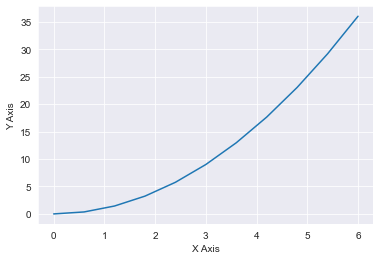

```python
x = np.linspace(0, 6, 11)
y = x ** 2

plt.plot(x, y)
plt.xlabel('X Axis')
plt.ylabel('Y Axis')
plt.show()
```

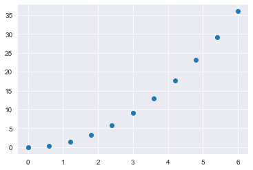

```python
plt.scatter(x,y)
plt.show()
```

**Bar Plot**

*When to use:* If you have comparative data that you would like to represent through a chart then a bar chart would be the best option. This type of chart is one of the more familiar options as it is easy to interpret. These charts are useful for displaying data that is classified into nominal or odinal categories.

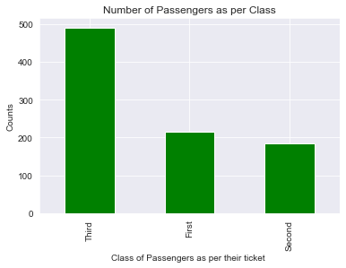

```python
# visualize counts
titanic['class'].value_counts().plot(kind='bar',color='g')
plt.title('Number of Passengers as per Class')
plt.ylabel('Counts')
plt.xlabel('Class of Passengers as per their ticket ')
plt.show()
```

**Pie Plot**

*when to use pie plot* :- A pie chart is best used when trying to work out the composition of something. If you have categorical data then using a pie chart would work really well as each slice can represent a different category.

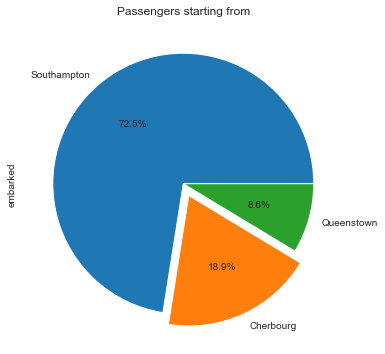

```python
z = titanic['embarked'].map({'C':'Cherbourg','Q':'Queenstown','S':'Southampton'})
#mapping to see full name of places of embarkment

plt.figure(figsize=(6,6))   # increase fifure size

z.value_counts().plot(kind='pie',explode = (0, 0.1, 0),autopct='%1.1f%%')
# explode is to remove one piece of pie
# autopct is to get percent on the pie chart

plt.title('Passengers starting from')
plt.show()
```

**Histogram plot** *When to use* :- A histogram is a great tool for quickly assessing a `probability distribution` that is intuitively understood by almost any audience. Python offers a handful of different options for building and plotting histograms. Most people know a histogram by its graphical representation, which is similar to a bar graph:

**Y-axis - Counts**

**X-axis - Continous Variable**

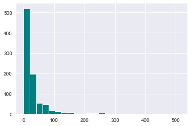

```python
plt.hist(titanic['fare'],bins=25,color='teal')
plt.show()
```

**Density Plot**

*What is the purpose of density plot/ kde-kernal density plot and where to be used* :-A Density Plot visualises the distribution of data over a continuous interval or time period. This chart is a variation of a Histogram that uses kernel smoothing to plot values, allowing for smoother distributions by smoothing out the noise. The peaks of a Density Plot help display where values are concentrated over the interval.

*An advantage Density Plots have over Histograms* :- is that they're better at determining the distribution shape because they're not affected by the number of bins used (each bar used in a typical histogram). A Histogram comprising of only 4 bins wouldn't produce a distinguishable enough shape of distribution as a 20-bin Histogram would. However, with Density Plots, this isn't an issue.

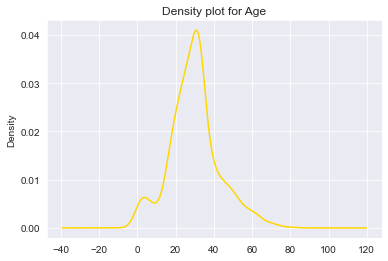

```python
titanic.age.plot(kind='kde', title='Density plot for Age', color='gold')
plt.show()
```

**Area plot**

*what is the purpose of Area plot* :-An area chart is a good way to demonstrate trends over time to the viewer,This chart is based on the line chart. The filled area can give a greater sense of the trends in a particular dataset.

```python
flights = sns.load_dataset("flights")

flights.head()
```

|  | year | month | passengers |
| --- | --- | --- | --- |
| 0 | 1949 | Jan | 112 |
| 1 | 1949 | Feb | 118 |
| 2 | 1949 | Mar | 132 |
| 3 | 1949 | Apr | 129 |
| 4 | 1949 | May | 121 |

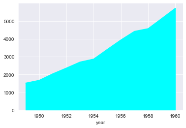

```python
flights.groupby('year')['passengers'].sum().sort_index().plot.area(color='cyan')
plt.show()
```

**Box plot**

**what is an boxplot:**

**---** A Box Plot is the visual representation of the statistical five number summary of a given data set.

Box and whisker plots have been used steadily since their introduction in 1969 and are varied in both their potential visualizations as well as use cases across many disciplines in statistics and data analysis.

**A Five Number Summary includes:-**

**Minimum** - Lowest value/record in that attribute/column .

**First Quartile** -25TH Percentile

**Median (Second Quartile)** - Middle value/record in that attribute/column .

**Third Quartile** - 75TH Percentile

**For example** in the number set where x = 1, 2, 3, 5, 6, 9, 10, 11, 12, 13

13 - **MAX**

7.5 - **MEDIAN**

3.5 - **Q1**

1 - **MIN**

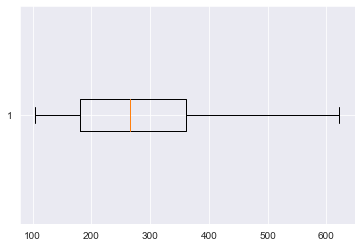

```python
plt.boxplot(flights.passengers,vert=False)
plt.show()
```

#### append vs extend

```python
l = [1,2,3,4,5]
l.append(6)
```

```python
l
```

```
[1, 2, 3, 4, 5, 6]
```

```python
l = [1,2,3,4,5,6]
l2 = [7,8]
l.extend(l2)
l
```

```
[1, 2, 3, 4, 5, 6, 7, 8]
```

#### When concatenating all Series along the index (axis=0), a Series is returned. When objs contains at least one DataFrame, a DataFrame is returned. When concatenating along the columns (axis=1), a DataFrame is returned.

```python
import pandas as pd
s1 = pd.Series(['a', 'b'])
s2 = pd.Series(['c', 'd'])

print(pd.concat([s1,s2]))
print(pd.concat([s1,s2],axis=1))
print()
print(pd.concat([s1+s2]))
```

```
0    a
1    b
0    c
1    d
dtype: object
   0  1
0  a  c
1  b  d

0    ac
1    bd
dtype: object
```

```python
m = np.array([[13,35,74,48], [23,37,37,38], [73,39,93,39]])
```

```python
m[:, (1,2)]
```

```
array([[35, 74],
       [37, 37],
       [39, 93]])
```